# Apple Stock - Time Series Analysis with ARIMA

### Time Series Analysis with ARIMA

This project aims to produce a model that can forecast the price of Apple Inc. stocks. The S&P500 will be used as an exogenous variable to strengthen model performance.

#### Import Packages

```python
import numpy as np
import pandas as pd
import scipy
import statsmodels.api as sm
import matplotlib.pyplot as plt
import seaborn as sns
import sklearn
import statsmodels.graphics.tsaplots as sgt
import statsmodels.tsa.stattools as sts
from statsmodels.tsa.stattools import adfuller
from statsmodels.tsa.seasonal import seasonal_decompose
from pmdarima.arima import auto_arima
from statsmodels.tsa.arima.model import ARIMA
from statsmodels.graphics.tsaplots import plot_acf
from statsmodels.graphics.tsaplots import plot_pacf
from statsmodels.tsa.stattools import kpss
from sklearn.metrics import mean_squared_error, mean_absolute_error
import math
import yfinance
import warnings
warnings.filterwarnings("ignore")
sns.set()
```

#### Importing the Data

```python
#Load the stock data for Apple Inc. (APPL) and the S&P500 (^GSPC) from Yahoo! Finance
raw_data = yfinance.download(tickers= "AAPL, ^GSPC", interval="1d",auto_adjust = True, treads=True, group_by='ticker')
raw_data
```

```
[*********************100%***********************]  2 of 2 completed
```

| Date | AAPL Open | AAPL High | AAPL Low | AAPL Close | AAPL Volume | ^GSPC Open | ^GSPC High | ^GSPC Low | ^GSPC Close | ^GSPC Volume |
| --- | --- | --- | --- | --- | --- | --- | --- | --- | --- | --- |
| 1950-01-03 | NaN | NaN | NaN | NaN | NaN | 16.660000 | 16.660000 | 16.660000 | 16.660000 | 1260000 |
| 1950-01-04 | NaN | NaN | NaN | NaN | NaN | 16.850000 | 16.850000 | 16.850000 | 16.850000 | 1890000 |
| 1950-01-05 | NaN | NaN | NaN | NaN | NaN | 16.930000 | 16.930000 | 16.930000 | 16.930000 | 2550000 |
| 1950-01-06 | NaN | NaN | NaN | NaN | NaN | 16.980000 | 16.980000 | 16.980000 | 16.980000 | 2010000 |
| 1950-01-09 | NaN | NaN | NaN | NaN | NaN | 17.080000 | 17.080000 | 17.080000 | 17.080000 | 2520000 |
| ... | ... | ... | ... | ... | ... | ... | ... | ... | ... | ... |
| 2022-02-14 | 167.369995 | 169.580002 | 166.559998 | 168.880005 | 86062800.0 | 4412.609863 | 4426.220215 | 4364.839844 | 4401.669922 | 3466170000 |
| 2022-02-15 | 170.970001 | 172.949997 | 170.250000 | 172.789993 | 64286300.0 | 4429.279785 | 4472.770020 | 4429.279785 | 4471.069824 | 3363200000 |
| 2022-02-16 | 171.850006 | 173.339996 | 170.050003 | 172.550003 | 61177400.0 | 4455.750000 | 4489.549805 | 4429.680176 | 4475.009766 | 3478750000 |
| 2022-02-17 | 171.029999 | 171.910004 | 168.470001 | 168.880005 | 69387600.0 | 4456.060059 | 4456.060059 | 4373.810059 | 4380.259766 | 3596510000 |
| 2022-02-18 | 169.820007 | 170.541306 | 167.669998 | 167.860001 | 19319657.0 | 4384.569824 | 4394.600098 | 4363.600098 | 4367.990234 | 557231815 |

18152 rows × 10 columns

```python
#Make a copy of the raw data. Make a column for the closing prices of Apple and the S&P500 and delete other columns.
df = raw_data.copy()
df['spx'] = df['^GSPC'].Close[:]
df['apple'] = df['AAPL'].Close[:]
del df['^GSPC']
del df['AAPL']
```

```python
df.shape
```

```
(18152, 2)
```

```python
df.info()
```

```
<class 'pandas.core.frame.DataFrame'>
DatetimeIndex: 18152 entries, 1950-01-03 to 2022-02-18
Data columns (total 2 columns):
 #   Column     Non-Null Count  Dtype
---  ------     --------------  -----
 0   (spx, )    18152 non-null  float64
 1   (apple, )  10386 non-null  float64
dtypes: float64(2)
memory usage: 425.4 KB
```

```python
df.describe
```

```
<bound method NDFrame.describe of                     spx       apple

Date
1950-01-03    16.660000         NaN
1950-01-04    16.850000         NaN
1950-01-05    16.930000         NaN
1950-01-06    16.980000         NaN
1950-01-09    17.080000         NaN
...                 ...         ...
2022-02-14  4401.669922  168.880005
2022-02-15  4471.069824  172.789993
2022-02-16  4475.009766  172.550003
2022-02-17  4380.259766  168.880005
2022-02-18  4367.990234  167.860001

[18152 rows x 2 columns]>
```

#### Pre-processing the data

```python
# Assigning the Frequency and filling NA values values from the period immediately
#preceding the period with the missing value.
df =df.asfreq('b')
df = df.fillna(method = 'bfill')
```

#### Plot the closing prices

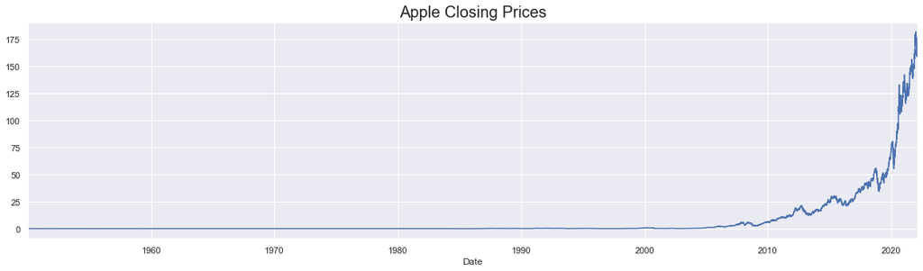

```python
#Visualize the closing price to see the overall price movement.
df['apple'].plot(figsize=(20,5))
plt.title('Apple Closing Prices', size=20)
plt.show()
```

The graph of the closing prices from the date when Apple was founded until 2005 is approximately flat so we will remove them from our analysis.

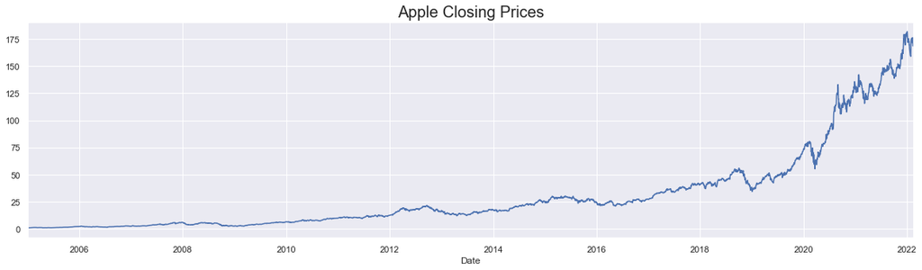

```python
df = df['2005-01-01':]
df['apple'].plot(figsize=(20,5))
plt.title('Apple Closing Prices', size=20)
plt.show()
```

```python
df.info()
```

[output not shown]

Check for seasonality year on year.

```python
#Make a temporary dataframe
df_temp = pd.DataFrame()
df_temp['Close'] = df.apple.copy()
df_temp
```

| Date | Close |
| --- | --- |
| 2005-01-03 | 0.967743 |
| 2005-01-04 | 0.977682 |
| 2005-01-05 | 0.986245 |
| 2005-01-06 | 0.987009 |
| 2005-01-07 | 1.058874 |
| ... | ... |
| 2022-02-09 | 176.279999 |
| 2022-02-10 | 172.119995 |
| 2022-02-11 | 168.639999 |
| 2022-02-14 | 168.880005 |
| 2022-02-15 | 172.789993 |

4467 rows × 1 columns

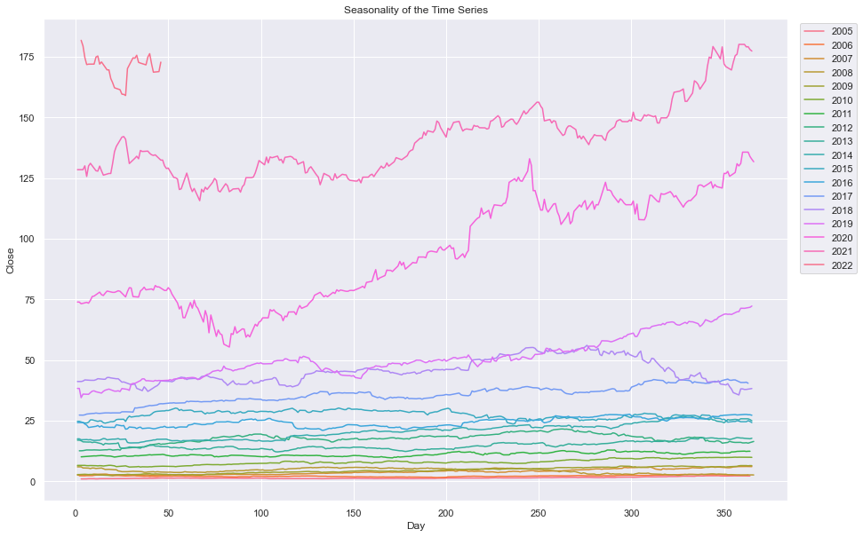

```python
#Extract the year, month and day of the year components of the date index and add columns for them.
df_temp['Year'] = pd.DatetimeIndex(df_temp.index).year
df_temp['Month'] = pd.DatetimeIndex(df_temp.index).month
df_temp['Day'] = pd.DatetimeIndex(df_temp.index).dayofyear
#Visualize the closing prices using a stacked line plot
plt.figure(figsize=(15,10))
plt.title('Seasonality of the Time Series')
fig = sns.lineplot(x='Day',y='Close', hue='Year', data=df_temp, palette='husl', legend='full')
fig.legend(loc='upper right', bbox_to_anchor=(1.1, 1))
```

The graph shows that in the first half of the time series data (2005-2015) the stock price was below \$25 with very low variance. The latter years in the dataset show that the price had greater variance and continuosly increased breaching \\$175. 2019-2021 showed a steeper upward trend compared to previous years.

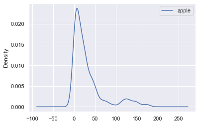

```python
df_close = pd.DataFrame()
df_close['apple'] = df['apple']
df_close.plot(kind='kde')
```

The kernel density estimate (KDE) plot shows the probability density of the stock price. The distribution of the price is concentrated from 0-\$50 price range. Some of the density is also in the \\$125 range as the price of Apple showed a sideways drift in this price range from mid 2020 to mid 2021 before it exhibit another upward trend.

#### Test for Stationarity: ADF Test

The Augmented Dickey Fuller test is a way to check the stationarity of a timeseries.

Null hypothesis : The data is non-stationary

Alternative Hhypothesis : The data is stationary

```python
#Define a function that performs the AD Fuller test on a time series and returns labeled results.
def adf_test(time_series):
    adft=adfuller(time_series, autolag='AIC')
    adft_result = pd.Series(adft[0:4], index=['Test Statistic', 'p-value', 'No.of lags used',
                                         'Number of observations used'])
    for key,values in adft[4].items():
        adft_result['critical value (%s)'%key] = values
    return adft_result

adf_test(df_close)
```

```
Test Statistic                    4.111537
p-value                           1.000000
No.of lags used                  26.000000
Number of observations used    4440.000000
critical value (1%)              -3.431824
critical value (5%)              -2.862191
critical value (10%)             -2.567117
dtype: float64
```

The ADFuller test shows a p-value of 1 which is significantly greater than the significance level of 0.05. The test statistics is also greater than the critical values. This means that the time series data is non-stationary. Since the data is non-stationary, we will use the ARIMA model since it is best suited for this type of data.

#### Seasonal Decomposition

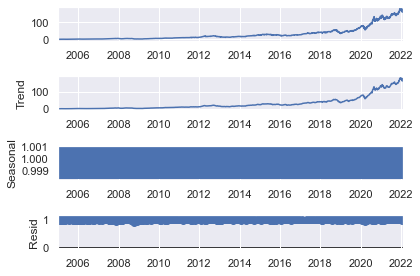

```python
decomposition = seasonal_decompose(df_close, model='multiplicative')
fig = plt.figure()
fig = decomposition.plot()
plt.show()
```

The figure above shows that there is no seasonality in the price of Apple stocks.

#### Differencing

```python
df_close_diff = df_close.diff(1)
df_close_diff.head()
```

| Date | apple |
| --- | --- |
| 2005-01-03 | NaN |
| 2005-01-04 | 0.009939 |
| 2005-01-05 | 0.008563 |
| 2005-01-06 | 0.000765 |
| 2005-01-07 | 0.071865 |

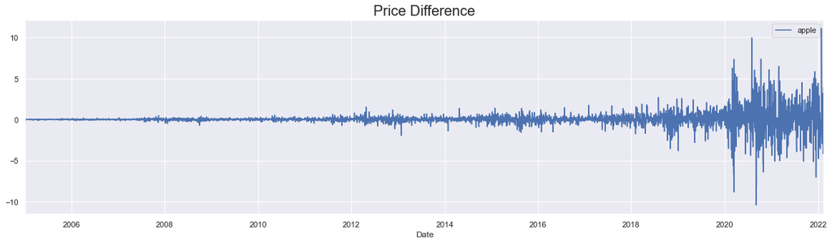

```python
df_close_diff[1:].plot(figsize=(20,5))
plt.title("Price Difference", size=20)
plt.show()
```

```python
adf_test(df_close_diff[1:])
```

```
Test Statistic                -1.164468e+01
p-value                        2.106040e-21
No.of lags used                3.200000e+01
Number of observations used    4.433000e+03
critical value (1%)           -3.431826e+00
critical value (5%)           -2.862192e+00
critical value (10%)          -2.567117e+00
dtype: float64
```

#### Log Transformation

```python
df_close_log = np.log(df_close)
df_close_log_diff = df_close_log.diff(1)
```

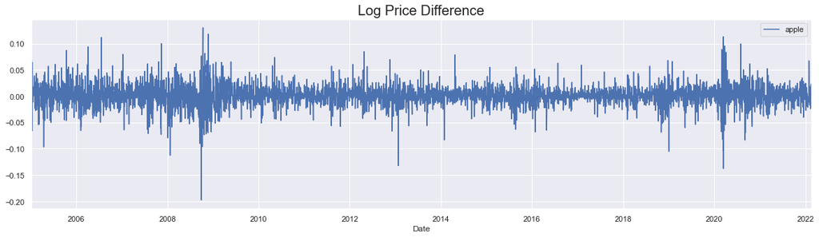

```python
df_close_log_diff[1:].plot(figsize=(20,5))
plt.title("Log Price Difference", size=20)
plt.show()
```

```python
adf_test(df_close_log_diff[1:])
```

```
Test Statistic                -1.543705e+01
p-value                        2.897798e-28
No.of lags used                1.500000e+01
Number of observations used    4.450000e+03
critical value (1%)           -3.431820e+00
critical value (5%)           -2.862190e+00
critical value (10%)          -2.567116e+00
dtype: float64
```

The AD fuller test shows a p-value of less that 0.05 and the test statistic is less than the critical value. This confirms that the data is now stationary. The graph shows that the variace is more constant aside from huge spikes in late 2008 and early 2020. These huge spikes pertain to the 2008 financial crisis and the start of the COVID-19 pandemic, respectively.

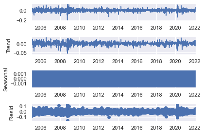

```python
#Recheck seasonal decomposition
decomposition = seasonal_decompose(df_close_log_diff[1:], model='additive')
fig = plt.figure()
fig = decomposition.plot()
plt.show()
```

#### KPSS Test

The KPSS test is another way to determine if a time series data is stationary or not. The null and alternative hypothesis of this test are the opposite that of the ADF test.

Null hypothesis : The data is stationary

Alternative Hhypothesis : The data is non-stationary

```python
def kpss_test(df_log_diff, **kw):
    statistic, p_value, n_lags, critical_values = kpss(df_log_diff, **kw)
    # Format Output
    print(f'KPSS Statistic: {statistic}')
    print(f'p-value: {p_value}')
    print(f'num lags: {n_lags}')
    print('Critial Values:')
    for key, value in critical_values.items():
        print(f'   {key} : {value}')
    print(f'Result: The series is {"not " if p_value < 0.05 else ""}stationary')

kpss_test(df_close_log_diff[1:])
```

```
KPSS Statistic: 0.07482534580362456
p-value: 0.1
num lags: 7
Critial Values:
   10% : 0.347
   5% : 0.463
   2.5% : 0.574
   1% : 0.739
Result: The series is stationary
```

The KPSS confirms the findings of the ADF test that our timeseries data "df_close_log_diff" is stationary.

#### Tranformation of the Exogenous variable

```python
#Apply the same transformations used on the endogenous variable (Apple) to the exogenous variable (S&P500).
df_spx = pd.DataFrame()
df_spx['spx'] = df['spx']
df_spx_log = np.log(df_spx)
df_spx_log_diff = df_spx_log.diff(1)
```

#### ACF and PACF

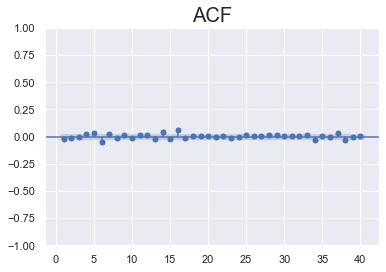

```python
plot_acf(df_close_log_diff[1:], zero=False, lags=40)
plt.title("ACF",size=20)
plt.show()
```

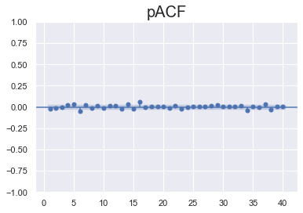

```python
plot_pacf(df_close_log_diff[1:], zero=False, lags=40)
plt.title("pACF",size=20)
plt.show()
```

#### Auto ARIMA Model

```python
#Split the data into train and test sets.
train_data, test_data = df_close_log_diff[1:int(len(df_close)*0.9)], df_close_log_diff[int(len(df_close)*0.9):]
spx_train, spx_test = df_spx_log_diff[1:int(len(df_spx)*0.9)], df_spx_log_diff[int(len(df_spx)*0.9):]
```

```python
#Train the model using auto ARIMA.
model_auto_arima = auto_arima(train_data, max_order=None, m=12, max_p=10, max_q=10, d=None, test='adf', max_P=4, max_Q=4,
                              max_D=2, maxiter=50, alpha=0.05, n_jobs=-1, information_criterion='aic',
                              seasononl=True, D=1, exogenous=(spx_train))
```

[output not shown]

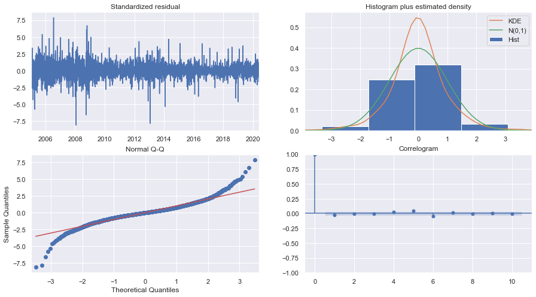

```python
print(model_auto_arima.summary())
model_auto_arima.plot_diagnostics(figsize=(15,8))
plt.show()
```

Bottom right: The ACF plot shows that the residual errors are not autocorrelated.

#### Make Predictions

```python
#Make predictions using the trained model.
df_pred = pd.DataFrame(model_auto_arima.predict(n_periods=len(test_data), exogenous=spx_test),
                       index=test_data.index, columns=['apple'])
```

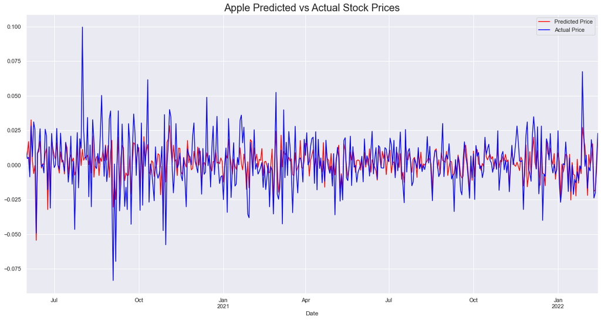

```python
#Visualize the predictions and compare with the actual data.
plt.figure()
ax = df_pred.plot(figsize=(20,10), color='red')
test_data.plot(color='blue', ax=ax)
plt.title("Apple Predicted vs Actual Stock Prices", size=20)
plt.legend(['Predicted Price','Actual Price'])
plt.show()
```

#### Evaluate Model Performance

In order to get interpretable measures of the model's performance, we need to reverse the transformations done on the data and do the same to the predictions.

```python
#Combine the train data set and predicted prices
data_with_pred = pd.concat([df_close_log_diff[0:int(len(df_close)*0.9)],df_pred])
data_with_pred
```

| Date | apple |
| --- | --- |
| 2005-01-03 | NaN |
| 2005-01-04 | 0.010217 |
| 2005-01-05 | 0.008720 |
| 2005-01-06 | 0.000775 |
| 2005-01-07 | 0.070282 |
| ... | ... |
| 2022-02-09 | 0.015320 |
| 2022-02-10 | -0.018949 |
| 2022-02-11 | -0.018145 |
| 2022-02-14 | -0.004815 |
| 2022-02-15 | 0.019039 |

4467 rows × 1 columns

```python
#The first value in the dataset is NaN because differencing could not be applied to first element since
#there is no prior element to it. Thus we fill in the missing value using the first element from the log transformation.
data_with_pred.iloc[0]=df_close_log.iloc[0]
data_with_pred
```

| Date | apple |
| --- | --- |
| 2005-01-03 | -0.032789 |
| 2005-01-04 | 0.010217 |
| 2005-01-05 | 0.008720 |
| 2005-01-06 | 0.000775 |
| 2005-01-07 | 0.070282 |
| ... | ... |
| 2022-02-09 | 0.015320 |
| 2022-02-10 | -0.018949 |
| 2022-02-11 | -0.018145 |
| 2022-02-14 | -0.004815 |
| 2022-02-15 | 0.019039 |

4467 rows × 1 columns

```python
#Reverse the transformation using .exp() and .cumsum()
df_close['prediction']=np.exp(data_with_pred.cumsum())
df_close['prediction']
```

```
Date
2005-01-03      0.967743
2005-01-04      0.977682
2005-01-05      0.986245
2005-01-06      0.987009
2005-01-07      1.058874
                 ...
2022-02-09    180.938796
2022-02-10    177.542491
2022-02-11    174.350056
2022-02-14    173.512583
2022-02-15    176.847755
Freq: B, Name: prediction, Length: 4467, dtype: float64
```

```python
df_close
```

| Date | apple | prediction |
| --- | --- | --- |
| 2005-01-03 | 0.967743 | 0.967743 |
| 2005-01-04 | 0.977682 | 0.977682 |
| 2005-01-05 | 0.986245 | 0.986245 |
| 2005-01-06 | 0.987009 | 0.987009 |
| 2005-01-07 | 1.058874 | 1.058874 |
| ... | ... | ... |
| 2022-02-09 | 176.279999 | 180.938796 |
| 2022-02-10 | 172.119995 | 177.542491 |
| 2022-02-11 | 168.639999 | 174.350056 |
| 2022-02-14 | 168.880005 | 173.512583 |
| 2022-02-15 | 172.789993 | 176.847755 |

4467 rows × 2 columns

```python
#Retrieve the actual and predicted prices for the dates covered by the prediction (10% of the dataset).
actual = df_close['apple'][test_data.index]
prediction = df_close['prediction'][test_data.index]
```

```python
#Calculate and report model performance scores.
mse = mean_squared_error(actual, prediction)
print('MSE: '+str(mse))
mae = mean_absolute_error(actual, prediction)
print('MAE: '+str(mae))
rmse = math.sqrt(mean_squared_error(actual, prediction))
print('RMSE: '+str(rmse))
```

```
MSE: 196.31424103658733
MAE: 12.499465857763886
RMSE: 14.011218399432197
```

The model has an RMSE of 14.01. This means that the model is able to predict the price of Apple stocks but it will be off by about $14.